# Lab 1 – The Basics of Python and Pytorch

#### 吴嘉骜 21307130203

### Import all necessary libraries

```python
import torch
import torch.nn as nn
from torch.utils.data import DataLoader
import torchvision
import torchvision.transforms as transforms

import matplotlib.pyplot as plt
from PIL import Image

import random
import re
import numpy as np

from sklearn.model_selection import train_test_split
from sklearn.linear_model import LinearRegression as LinearR
from sklearn.linear_model import LogisticRegression as LogisticR
from sklearn.svm import SVC

import pickle

import warnings
warnings.filterwarnings("ignore", category=UserWarning)
```

### 1. Write a Python function to sum all the numbers in a list.

```python
def sum_list(arr):
    if len(arr) == 0:
        return 0
    return arr[0] + sum_list(arr[1:])

arr = [1, 2, 3, 4, 5]
print(sum_list(arr))
```

```
15
```

### 2. Write a Python function that takes a list and returns a new list with unique elements of the first list.

```python
def dedup_list(arr):
    new_arr = []
    for i in arr:
        if i not in new_arr:
            new_arr.append(i)
    return new_arr

arr = [1, 2, 3, 3, 3, 3, 4, 5]
print(dedup_list(arr))
```

```
[1, 2, 3, 4, 5]
```

### 3. Write a Python function that checks whether a passed string is palindrome or not. A palindrome is a word, phrase, or sequence that reads the same backward as forward.

```python
def check_palindrome(s):
    s = "".join(s.split())
    # return s == s[::-1]
    for i in range(len(s) // 2):
        if s[i] != s[-i-1]:
            return False
    return True

s = "nurses run"
print(check_palindrome(s))
```

```
True
```

### 4. Write a NumPy program to find the real and imaginary parts of an array of complex numbers.

```python
def find_re_im_arr(arr):
    arr = np.array(arr)
    return np.column_stack((arr.real, arr.imag))

arr = [1.00000000+0.j, 0.70710678+0.70710678j]
print(find_re_im_arr(arr))
```

```
[[1.         0.        ]
 [0.70710678 0.70710678]]
```

### 5. Write a Python program to add two binary numbers.

```python
def add_binary1(bins):
    '''Use int() function.'''
    bin1, bin2 = bins
    # Convert the binary strings to integers
    int1 = int(bin1, 2)
    int2 = int(bin2, 2)

    # Add the integers
    sum_integer = int1 + int2

    # Convert the sum back to binary
    sum_binary = format(sum_integer, 'b')

    return sum_binary

print(add_binary1(("11", "1")))
```

```
100
```

```python
def add_binary2(nums):
    '''Manually add the binary strings.'''
    a, b = nums
    carry = 0
    ans = ''
    len_a = len(a)
    len_b = len(b)
    # Make the two strings the same length
    if len_a < len_b:
        a = "0" * (len_b - len_a) + a
    else:
        b = "0" * (len_a - len_b) + b

    # Traverse both strings from the end to the beginning
    for i in range(len_a - 1, -1, -1):
        bit_sum = carry
        bit_sum += 1 if a[i] == '1' else 0
        bit_sum += 1 if b[i] == '1' else 0
        carry = bit_sum // 2
        ans = str(bit_sum % 2) + ans
    if carry:
        ans = '1' + ans

    return ans

print(add_binary2(("11", "1")))
```

```
100
```

### 6. You are given two non-empty linked lists representing two non-negative integers.

The digits are stored in reverse order and each of their nodes contain a single digit. Add the two numbers and return it as a linked list. You may assume the two numbers do not contain any leading zero, except the number 0 itself.

```python
# Definition for singly-linked list.
class ListNode:
    def __init__(self, x):
        self.val = x
        self.next = None

def add_two_numbers(l1, l2):
    head = None
    cur = None
    carry = 0 # carry over from the previous sum
    while l1 or l2:
        sumval = (0 if l1 is None else l1.val) + (0 if l2 is None else l2.val) + carry
        carry = sumval // 10
        sumval = sumval % 10
        if head is None:
            head = ListNode(sumval)
            cur = head
        else:
            cur.next = ListNode(sumval)
            cur = cur.next
        l1 = None if l1 is None else l1.next
        l2 = None if l2 is None else l2.next
    if carry > 0:
        cur.next = ListNode(1)

    return head

l1 = ListNode(2)
l1.next = ListNode(4)
l1.next.next = ListNode(3)
l2 = ListNode(5)
l2.next = ListNode(6)
l2.next.next = ListNode(4)
result = add_two_numbers(l1, l2)
while result:
    print(result.val)
    result = result.next
```

```
7
0
8
```

### 7. Implement bubble sort

```python
def bubble_sort(arr):
    n = len(arr)
    if n < 2:
        return arr
    for i in range(n-1, 0, -1):
        for j in range(i):
            if arr[j] > arr[j+1]:
                arr[j], arr[j+1] = arr[j+1], arr[j]
    return arr

arr = [64, 34, 25, 12, 22, 11, 90]
print(bubble_sort(arr))
```

```
[11, 12, 22, 25, 34, 64, 90]
```

### 8. Implement merge sort

```python
def sort_array(arr):
    n = len(arr)
    helparr = [0] * n

    def merge_sort(arr, l ,r):
        if l == r:
            return
        mid = (l + r) // 2
        merge_sort(arr, l, mid)
        merge_sort(arr, mid+1, r)
        merge(arr, l, mid, r)

    def merge(arr, l, m, r):
        p1, p2 = l, m+1 # pointers to the two subarrays
        cur = l # pointer to the current position in the help array
        while p1 <= m and p2 <= r:
            if arr[p1] <= arr[p2]:
                helparr[cur] = arr[p1]
                p1 += 1
                cur += 1
            else:
                helparr[cur] = arr[p2]
                p2 += 1
                cur += 1

        if p1 <= m:  # copy the remaining elements of the first subarray
            helparr[cur:r+1] = arr[p1:m+1]

        if p2 <= r:  # copy the remaining elements of the second subarray
            helparr[cur:r+1] = arr[p2:r+1]

        arr[l:r+1] = helparr[l:r+1]

    merge_sort(arr, 0, n-1)

    return arr

arr = [64, 34, 25, 12, 22, 11, 9, 10, 104]
print(sort_array(arr))
```

```
[9, 10, 11, 12, 22, 25, 34, 64, 104]
```

### 9. Implement quick sort

```python
def sort_array(arr):

    def quick_sort(arr, l, r):
        if l >= r:
            return
        x = arr[l + random.randint(0, r - l)]
        mid = partition(arr, l, r, x)
        quick_sort(arr, l, mid - 1)
        quick_sort(arr, mid + 1, r)

    def partition(arr, l, r, x):
        p = l  # pointer to the current position
        for i in range(l, r + 1):
            if arr[i] <= x:
                arr[p], arr[i] = arr[i], arr[p]
                if arr[p] == x:
                    xi = p  # record a position of the pivot element
                p += 1
        arr[p - 1], arr[xi] = arr[xi], arr[p - 1]

        return p - 1

    if len(arr) > 1:
        quick_sort(arr, 0, len(arr)-1)

    return arr

arr = [64, 34, 25, 12, 22, 11, 9, 10, 104]
print(sort_array(arr))
```

```
[9, 10, 11, 12, 22, 25, 34, 64, 104]
```

### 10. Implement shell sort

```python
def shell_sort(arr):
    n = len(arr)
    gap = n // 2
    while gap > 0:
        for i in range(gap, n):
            temp = arr[i]
            j = i
            while j >= gap and arr[j - gap] > temp:
                arr[j] = arr[j - gap]
                j -= gap
            arr[j] = temp
        gap //= 2
    return arr


arr = [64, 34, 25, 12, 22, 11, 9, 10, 104]
print(shell_sort(arr))
```

```
[9, 10, 11, 12, 22, 25, 34, 64, 104]
```

### 11. Implement linear regression model and use autograd to optimize it by Pytorch.

A linear regression model is defined as $f(x) = w^T x + b$, where $w^T = [w_1,w_2,...,w_k]$.

We first create a synthetic dataset by given parameters $w$ and $b$, and add some noise. Then we use Pytorch to optimize the model by minimizing the Mean Squared Error (MSE) loss function.

The MSE loss function is defined as $J(x) = \frac{1}{n} \sum_{i=1}^{n} (f(x^{(i)})-y^{(i)})^2$.

We use the autograd feature of Pytorch to compute the gradients of the loss function with respect to the parameters, and use the gradient descent algorithm to update the parameters iteratively.

```
Epoch: 100/1000, Loss: 5.6714
Epoch: 200/1000, Loss: 5.5442
Epoch: 300/1000, Loss: 5.4972
Epoch: 400/1000, Loss: 5.4798
Epoch: 500/1000, Loss: 5.4734
Epoch: 600/1000, Loss: 5.4710
Epoch: 700/1000, Loss: 5.4701
Epoch: 800/1000, Loss: 5.4698
Epoch: 900/1000, Loss: 5.4697
Epoch: 1000/1000, Loss: 5.4696
Estimated w = 1.9981213808059692
Estimated b = 1.0353318452835083
```

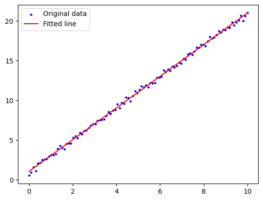

```python
def generate_data(w, b):
    """
    Generates linear data based on a given slope (w) and y-intercept (b).
    Noise is added to the y-values to simulate real-world data.

    Args:
        w (float): The slope of the line.
        b (float): The y-intercept of the line.

    Returns:
        tuple: A tuple containing the generated x and y values as tensors.
    """
    x = torch.linspace(0, 10, 100).unsqueeze(
        dim=1)  # Create 100 linearly spaced points between 0 and 10.
    # Apply the linear equation and add random noise.
    y = w * x + b + torch.randn(x.shape) * 0.25
    return x, y


class LinearRegression(torch.nn.Module):
    def __init__(self):
        super(LinearRegression, self).__init__()
        # Linear layer with a single input and a single output.
        self.linear = torch.nn.Linear(1, 1)

    def forward(self, x):
        """
        Forward pass of the model.

        Args:
            x (tensor): The input features.

        Returns:
            tensor: The predicted outputs.
        """
        y_pred = self.linear(x)
        return y_pred


# Initialize the model
model = LinearRegression()
criterion = torch.nn.MSELoss(reduction='sum')  # Mean Squared Error Loss
optimizer = torch.optim.SGD(model.parameters(), lr=0.0001)

# Generate synthetic data
true_w = 2
true_b = 1
x, y = generate_data(true_w, true_b)

# Training loop
num_epochs = 1000
for epoch in range(num_epochs):
    y_pred = model(x)
    loss = criterion(y_pred, y)  # Compute loss
    if (epoch+1) % 100 == 0:
        print(f"Epoch: {epoch+1}/{num_epochs}, Loss: {loss.item():.4f}")

    # Zero the gradients before running the backward pass.
    optimizer.zero_grad()
    loss.backward()  # Backward pass
    optimizer.step()  # Update the weights

# Display the results
print(f'Estimated w = {model.linear.weight.item()}')
print(f'Estimated b = {model.linear.bias.item()}')

# Plot the original data and the linear regression line
plt.scatter(x, y, label='Original data', color='blue', s=5)
predicted_y = x * model.linear.weight.item() + model.linear.bias.item()
plt.plot(x, predicted_y, color='red', label='Fitted line')
plt.legend()
plt.show()
```

We can observe that the estimated parameters are close to the true parameters.

### 12. Implement logistic regression model and use autograd to optimize it by Pytorch.

A logistic regression model is defined as $f(x) = \frac{1}{1+e^{-(w^T x + b)}}$, where $w^T = [w_1,w_2,...,w_k]$.

We generate a synthetic dataset by simply sampling normally distributed data points, and assign labels according to a linear boundary.

Then we use Pytorch to optimize the model by minimizing the Binary Cross Entropy (BCE) loss function, i.e.,

$J(x) = -\frac{1}{n} \sum_{i=1}^{n} y^{(i)} \log(f(x^{(i)})) + (1-y^{(i)}) \log(1-f(x^{(i)}))$.

[output not shown]

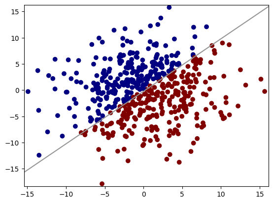

```python
def generate_data(num_samples):
    """
    Generates random data points based on a linear equation.

    Args:
        num_samples (int): The number of data points to generate.

    Returns:
        tuple: A tuple containing the generated x and y values as tensors.
    """
    x = torch.randn(num_samples, 2) * 5  # Generate random x values
    # Generate y values based on x1 - x2
    y = (x[:, 0] - x[:, 1] > 0).to(torch.float32)
    return torch.tensor(x, dtype=torch.float32), torch.tensor(y, dtype=torch.float32)


class LogisticRegressionModel(nn.Module):
    def __init__(self, n_feature, n_output):
        """
        Initializes the logistic regression model with a single linear layer followed by a sigmoid activation.

        Args:
            n_feature (int): The number of features in the input data.
            n_output (int): The number of output classes.
        """
        super(LogisticRegressionModel, self).__init__()
        self.linear = nn.Linear(n_feature, n_output)  # Linear layer
        self.sigmoid = nn.Sigmoid()  # Sigmoid activation function

    def forward(self, x):
        x = self.linear(x)
        y_pred = self.sigmoid(x)
        return y_pred


# Generate synthetic data
x, y = generate_data(500)

# Initialize the model and optimizer
model = LogisticRegressionModel(2, 1)
criterion = nn.BCELoss()  # Binary Cross-Entropy Loss
optimizer = torch.optim.SGD(model.parameters(), lr=0.01)

# Training loop
num_epochs = 1000
for epoch in range(num_epochs):
    # Forward pass
    y_pred = model(x).squeeze()

    loss = criterion(y_pred, y)  # Calculate loss
    if (epoch+1) % 100 == 0:
        print(f'Epoch {epoch+1}/{num_epochs}, Loss: {loss.item():.4f}')

    optimizer.zero_grad()
    loss.backward()
    optimizer.step()

# Calculate the accuracy of the model
with torch.no_grad():
    predictions = model(x).squeeze() >= 0.5
    accuracy = (predictions == y).float().mean()
    print(f'Accuracy: {accuracy.item():.4f}')

# Visualize the data and decision boundary
def vis_result(x, y, model):
    plt.scatter(x[:, 0], x[:, 1], c=y, cmap=plt.cm.jet)
    x0_min, x0_max = x[:, 0].min() - 0.5, x[:, 0].max() + 0.5
    x1_min, x1_max = x[:, 1].min() - 0.5, x[:, 1].max() + 0.5
    xx, yy = np.meshgrid(np.linspace(x0_min, x0_max, 100),
                         np.linspace(x1_min, x1_max, 100))
    grid = torch.tensor(np.c_[xx.ravel(), yy.ravel()], dtype=torch.float32)
    with torch.no_grad():
        probs = model(grid).reshape(xx.shape)
    plt.contour(xx, yy, probs, levels=[0.5], cmap="Greys", vmin=0, vmax=1)
    plt.show()


print("Weights:")
print(model.linear.weight.data)
print("Bias:")
print(model.linear.bias.data)
vis_result(x.numpy(), y.numpy(), model)
```

### 13. Implement linear SVM model for binary classification task and use autograd to optimize it by Pytorch.

A linear SVM model aims to classify data points by finding the optimal hyperplane that separates different classes with the largest margin. The model is represented as $f(x) = W^T x + b$, where $W^T = [w_1, w_2, ..., w_k]$ and $b$ is the bias term. We define the decision boundary such that $f(x) = 0$.

The loss function, known as the hinge loss, is defined as:

$$ L(W) = \sum_{i=1}^{n} \max(0, 1 - y^{(i)}(W^T x^{(i)} + b)), $$

where $y^{(i)} \in \{-1, 1\}$ is the label for each data point $x^{(i)}$, and $n$ is the number of data points in the dataset.

```
Epoch [1000/10000], Loss: 0.0375
Epoch [2000/10000], Loss: 0.0215
Epoch [3000/10000], Loss: 0.0133
Epoch [4000/10000], Loss: 0.0103
Epoch [5000/10000], Loss: 0.0083
Epoch [6000/10000], Loss: 0.0070
Epoch [7000/10000], Loss: 0.0056
Epoch [8000/10000], Loss: 0.0043
Epoch [9000/10000], Loss: 0.0036
Epoch [10000/10000], Loss: 0.0035
Weights:
tensor([[0.1698, 1.9342]])
Bias:
tensor([1.4684])
```

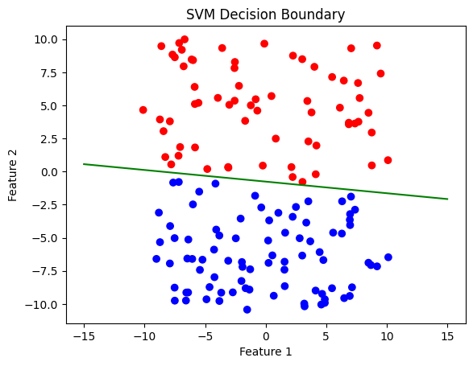

```python
def generate_data(w, b, n, distance_threshold=4):
    """
    Generates linearly separable data with features distributed on either side of the decision boundary.

    Parameters:
    - w: Weight vector for the decision boundary.
    - b: Bias term for the decision boundary.
    - n: Number of data points to generate.
    - distance_threshold: Minimum distance threshold from the decision boundary for the data points.

    Returns:
    - x: Tensor containing the features.
    - y: Tensor containing the labels.
    """
    dim = len(w)  # Dimensionality of the features
    x = np.zeros((n, dim))
    y = np.zeros(n)
    torch.manual_seed(203)
    for i in range(n):
        while True:
            # Generate a random point
            point = np.random.uniform(-10, 10, dim)
            # Calculate the distance from the decision boundary
            distance = (np.dot(point, w) + b)
            # Check if the point is beyond the distance threshold from the decision boundary
            if abs(distance) >= distance_threshold:
                x[i] = point
                y[i] = 1 if distance > 0 else -1
                break

    # Add Gaussian noise to the features
    x += np.random.normal(0, 0.5, x.shape)

    return torch.tensor(x, dtype=torch.float32), torch.tensor(y, dtype=torch.float32).reshape(-1, 1)

class SVM(nn.Module):
    def __init__(self, n_feature, n_output):
        super(SVM, self).__init__()
        self.linear = nn.Linear(n_feature, n_output)

    def forward(self, x):
        return self.linear(x)


def hinge_loss(outputs, labels):
    labels = labels.squeeze()
    return torch.mean(torch.clamp(1 - outputs * labels, min=0))

w = np.array([1, 10])
b = 10
n = 150
x, y = generate_data(w, b, n)

model = SVM(2, 1)
optimizer = torch.optim.SGD(model.parameters(), lr=0.01)

num_epochs = 10000
for epoch in range(num_epochs):
    outputs = model(x).squeeze()  # Ensure outputs are squeezed for hinge loss calculation
    loss = hinge_loss(outputs, y)

    optimizer.zero_grad()
    loss.backward()
    optimizer.step()

    if (epoch+1) % 1000 == 0:
        print(f'Epoch [{epoch+1}/{num_epochs}], Loss: {loss.item():.4f}')


def vis_result(x, y, model):
    w = model.linear.weight[0].detach().numpy()
    b = model.linear.bias[0].detach().numpy()

    plt.scatter(x[:, 0], x[:, 1], c=y, cmap=plt.cm.bwr)
    x_axis = np.linspace(-15, 15, 100)
    y_axis = -(w[0] * x_axis + b) / w[1]
    plt.plot(x_axis, y_axis, '-g')
    plt.xlabel('Feature 1')
    plt.ylabel('Feature 2')
    plt.title('SVM Decision Boundary')
    plt.show()

print("Weights:")
print(model.linear.weight.data)
print("Bias:")
print(model.linear.bias.data)
vis_result(x, y, model)
```

We can see that the learned decision boundary is close to the true boundary.

### 14. Add a Frobenius norm penalty for the weight w in your SVM model by two different ways.

(1) use a pytorch function to calculate the norm;

```
Epoch [100/5000], Loss: 0.1626
Epoch [200/5000], Loss: 0.1506
Epoch [300/5000], Loss: 0.1441
Epoch [400/5000], Loss: 0.1400
Epoch [500/5000], Loss: 0.1365
Epoch [600/5000], Loss: 0.1330
Epoch [700/5000], Loss: 0.1299
Epoch [800/5000], Loss: 0.1282
Epoch [900/5000], Loss: 0.1267
Weights:
tensor([[0.0305, 0.5566]])
Bias:
tensor([0.2131])
```

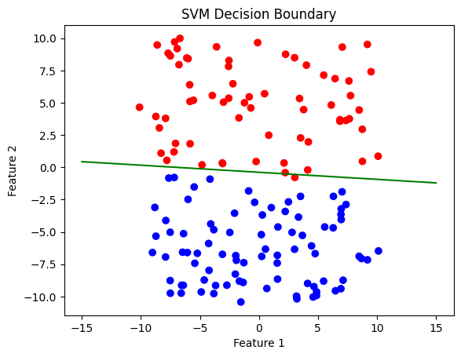

```python
lambda_ = 0.1  # Regularization strength
last_loss = float('inf')

model = SVM(2, 1)
optimizer = torch.optim.SGD(model.parameters(), lr=0.01)

num_epochs = 5000
for epoch in range(num_epochs):
    outputs = model(x).squeeze()
    loss = hinge_loss(outputs, y)

    frobenius_norm = torch.norm(model.linear.weight, p='fro')

    # add the regularization term to the loss
    loss += lambda_ * frobenius_norm

    optimizer.zero_grad()
    loss.backward()
    optimizer.step()

    if (epoch+1) % 100 == 0:
        print(f'Epoch [{epoch+1}/{num_epochs}], Loss: {loss.item():.4f}')

    if abs(last_loss-loss) < 1e-6:
        break

    last_loss = loss

print("Weights:")
print(model.linear.weight.data)
print("Bias:")
print(model.linear.bias.data)
vis_result(x, y, model)
```

(2) implement the code by yourself.

```
Epoch [100/5000], Loss: 0.1662
Epoch [200/5000], Loss: 0.1560
Epoch [300/5000], Loss: 0.1487
Epoch [400/5000], Loss: 0.1414
Epoch [500/5000], Loss: 0.1354
Epoch [600/5000], Loss: 0.1310
Epoch [700/5000], Loss: 0.1282
Epoch [800/5000], Loss: 0.1269
Weights:
tensor([[0.0294, 0.5809]])
Bias:
tensor([0.2035])
```

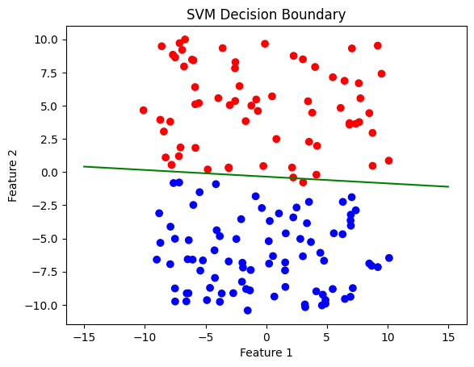

```python
lambda_ = 0.1  # Regularization strength
last_loss = float('inf')

model = SVM(2, 1)
optimizer = torch.optim.SGD(model.parameters(), lr=0.01)

num_epochs = 5000
for epoch in range(num_epochs):
    outputs = model(x).squeeze()
    loss = hinge_loss(outputs, y)

    frobenius_norm = (model.linear.weight ** 2).sum().sqrt()

    # add the regularization term to the loss
    loss += lambda_ * frobenius_norm

    optimizer.zero_grad()
    loss.backward()
    optimizer.step()

    if (epoch+1) % 100 == 0:
        print(f'Epoch [{epoch+1}/{num_epochs}], Loss: {loss.item():.4f}')

    if abs(last_loss-loss) < 1e-6:
        break

    last_loss = loss

print("Weights:")
print(model.linear.weight.data)
print("Bias:")
print(model.linear.bias.data)
vis_result(x, y, model)
```

### 15. Learn how to use linear regression, logistic regression, and SVM by scikit-learn.

Linear regression by scikit-learn

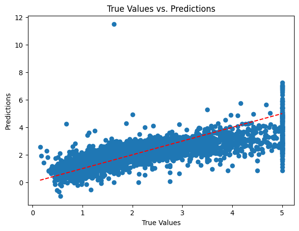

```python
from sklearn.datasets import fetch_california_housing


# Load the dataset
housing = fetch_california_housing()
X = housing.data
y = housing.target

X_train, X_test, y_train, y_test = train_test_split(
    X, y, test_size=0.2, random_state=42)

# Initialize the linear regression model
lr = LinearR()

lr.fit(X_train, y_train)

# Make predictions
predictions = lr.predict(X_test)

plt.figure(figsize=(7, 5))
plt.scatter(y_test, predictions)
plt.plot([min(y_test), max(y_test)], [min(y_test), max(y_test)], '--r')  # Add a diagonal line y=x for comparison
plt.xlabel('True Values')
plt.ylabel('Predictions')
plt.title('True Values vs. Predictions')
plt.show()
```

Logisitc regression by scikit-learn

```python
from sklearn.datasets import load_breast_cancer

# Load the dataset
X, y = load_breast_cancer(return_X_y=True)

X_train, X_test, y_train, y_test = train_test_split(
    X, y, test_size=0.2, random_state=42)

# Initialize the logistic regression model
log_reg = LogisticR(max_iter=10000)

log_reg.fit(X_train, y_train)

# Make predictions
predictions = log_reg.predict(X_test)

print(f'Accuracy: {log_reg.score(X_test, y_test):.4f}')
```

```
Accuracy: 0.9561
```

SVM by scikit-learn

```python
from sklearn.datasets import load_breast_cancer

# Load the dataset
X, y = load_breast_cancer(return_X_y=True)

X_train, X_test, y_train, y_test = train_test_split(
    X, y, test_size=0.2, random_state=42)

# Initialize the Support Vector Classifier
svc = SVC()

svc.fit(X_train, y_train)

# Make predictions
predictions = svc.predict(X_test)

print(f'Accuracy: {svc.score(X_test, y_test):.4f}')
```

```
Accuracy: 0.9474
```

### 16. Download CIFAR-10 dataset4 and visualize some of its images.

References for Task 16-20:

- https://pytorch.org/tutorials/beginner/blitz/cifar10_tutorial.html
- https://www.cs.toronto.edu/~kriz/cifar.html

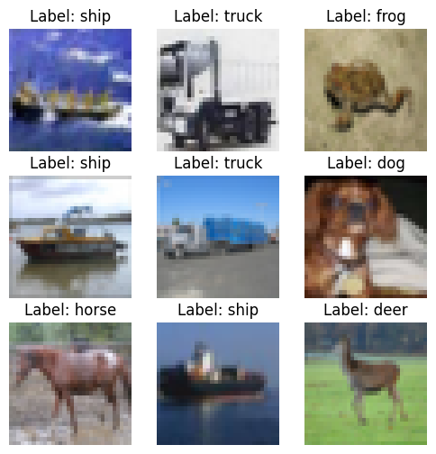

```python
def unpickle(file):
    with open(file, 'rb') as fo:
        dict = pickle.load(fo, encoding='bytes')
    return dict

meta_dict = unpickle(
    "./data/cifar-10-batches-py/batches.meta")

# select the first batch
data = unpickle('./data/cifar-10-batches-py/data_batch_1')

# extract figures and labels
X = data[b'data']
y = data[b'labels']
class_names = meta_dict[b'label_names']
class_names = [name.decode('utf-8') for name in class_names]

# randomly choose 9 images
indices = np.random.choice(len(X), 9)
images = [X[i].reshape(3, 32, 32) for i in indices]
labels = [y[i] for i in indices]

fig, axes = plt.subplots(3, 3, figsize=(6, 6))

for i, ax in enumerate(axes.flat):
    ax.imshow(np.transpose(images[i], (1, 2, 0)))
    ax.set_title(f"Label: {class_names[labels[i]]}")
    ax.axis('off')

plt.show()
```

### 17. Write a dataset class for loading CIFAR-10.

Make sure it could be transferred to Pytorch Dataloader. The class should meet the following requirements: (1) Inherit pytorch’s DataSet class; (2) Load the image file and save in proper way; (3) Override `__getitem__` and `__len__` methods.

```
Number of samples in the dataset: 10000
Label: airplane
```

[figure not shown]

```python
class CIFAR10_loader(torch.utils.data.Dataset):
    def __init__(self, file_path, transform=None):
        """
        Args:
            file_path (string): Path to the pickle file with CIFAR-10 data.
            transform: Optional transform to be applied on a sample.
        """
        self.file_path = file_path
        self.transform = transform
        self.data, self.labels = self.load_cifar10(file_path)

    def load_cifar10(self, file_path):
        with open(file_path, 'rb') as fo:
            cifar_dict = pickle.load(fo, encoding='bytes')
        # Reshape the data to the format (num_samples, 3, 32, 32)
        images = cifar_dict[b'data'].reshape(-1, 3, 32, 32).astype('float32')
        labels = cifar_dict[b'labels']
        return images, labels

    def __len__(self):
        # Return the number of images
        return len(self.labels)

    def __getitem__(self, idx):
        # Return one image and its label
        image = self.data[idx]
        label = self.labels[idx]
        image = Image.fromarray(image.transpose(
            1, 2, 0).astype('uint8'), 'RGB')

        if self.transform:
            image = self.transform(image)

        return image, label

# Instantiate the dataset with data_batch_4 file
dataset = CIFAR10_loader(
    './data/cifar-10-batches-py/data_batch_4')

# Create a DataLoader
data_loader = DataLoader(dataset, batch_size=64, shuffle=True)

print(f'Number of samples in the dataset: {len(dataset)}')

# show the first image
with open("./data/cifar-10-batches-py/batches.meta", 'rb') as fo:
    meta_dict = pickle.load(fo, encoding='bytes')

class_names = [name.decode('utf-8') for name in meta_dict[b'label_names']]

image, label = dataset[0]
plt.figure(figsize=(4, 4))
plt.axis('off')
plt.imshow(image)
print(f'Label: {class_names[label]}')
```

### 18. Read and learn how to use `torchvision.transforms` to transform images.

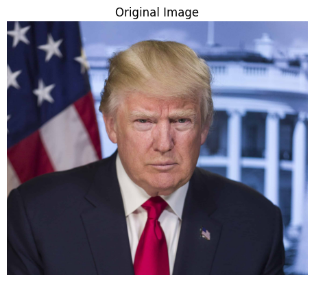

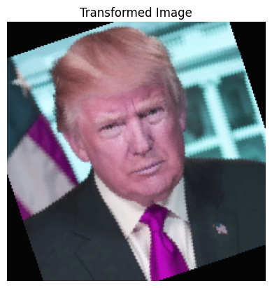

```
Image size: torch.Size([3, 224, 224])
Image mean (per channel): tensor([0.4157, 0.3943, 0.4435])
Image standard deviation (per channel): tensor([0.2790, 0.2813, 0.2812])
```

```python
image_path = './Trump.jpg'

# Define the transformation
transform = transforms.Compose([
    transforms.Resize(256),  # Resize the input image to 256x256 pixels
    transforms.CenterCrop(224),  # Crop a central 224x224 patch
    transforms.RandomAffine(30),  # Apply random affine transformation
    transforms.RandomHorizontalFlip(),  # Randomly flip the image horizontally
    transforms.ColorJitter(brightness=0.1, contrast=0.1, saturation=0.1, hue=0.1),  # Adjust the image color
    transforms.ToTensor(),  # Convert the image to PyTorch tensor
])

# Load the image and convert it to RGB
image = Image.open(image_path).convert('RGB')

# Display the original image
plt.imshow(image)
plt.title('Original Image')
plt.axis('off')
plt.show()

# Apply the transformation
transformed_image = transform(image)

# Convert the transformed tensor back to an image
image_transformed = transforms.ToPILImage()(transformed_image)

# Display the transformed image
plt.imshow(image_transformed)
plt.title('Transformed Image')
plt.axis('off')
plt.show()

# Print details about the transformed image
print(f'Image size: {transformed_image.size()}')
print(f'Image mean (per channel): {torch.mean(transformed_image, dim=(1, 2))}')
print(f'Image standard deviation (per channel): {torch.std(transformed_image, dim=(1, 2))}')
```

### 19. Run one epoch for loading CIFAR-10 with Pytorch Dataloader

and test the loading time of different `batch_size` (1, 4, 64, 1024), different `num_workers` (0,1,4,16), and whether use pin_memory or not.

```python
import time

transform = transforms.Compose([transforms.ToTensor()])

# Load CIFAR-10 dataset
trainset = torchvision.datasets.CIFAR10(root='./data', train=True, transform=transform)


def load_run_epoch(batch_size, num_workers, pin_memory):
    start_time = time.perf_counter()
    trainloader = DataLoader(
        trainset, batch_size=batch_size, shuffle=True, num_workers=num_workers, pin_memory=pin_memory)
    loading_time = time.perf_counter() - start_time

    # run one epoch, comment out for time saving
    # for i, data in enumerate(trainloader, 0):
    #     inputs, labels = data

    print(f"Batch Size: {batch_size}, Num Workers: {num_workers}, Pin Memory: {pin_memory}, Time Taken: {loading_time:.8f}s")


batch_sizes = [1, 4, 64, 1024]
num_workers_list = [0, 1, 4, 16]
pin_memory_options = [False, True]

for batch_size in batch_sizes:
    load_run_epoch(batch_size, num_workers_list[2], pin_memory_options[0])
print("\n")
for num_workers in num_workers_list:
    load_run_epoch(batch_sizes[2], num_workers, pin_memory_options[0])
print("\n")
for pin_memory in pin_memory_options:
    load_run_epoch(batch_sizes[2], num_workers_list[2], pin_memory)
```

```
Batch Size: 1, Num Workers: 4, Pin Memory: False, Time Taken: 0.00013440s
Batch Size: 4, Num Workers: 4, Pin Memory: False, Time Taken: 0.00005450s
Batch Size: 64, Num Workers: 4, Pin Memory: False, Time Taken: 0.00004120s
Batch Size: 1024, Num Workers: 4, Pin Memory: False, Time Taken: 0.00004080s


Batch Size: 64, Num Workers: 0, Pin Memory: False, Time Taken: 0.00004420s
Batch Size: 64, Num Workers: 1, Pin Memory: False, Time Taken: 0.00004200s
Batch Size: 64, Num Workers: 4, Pin Memory: False, Time Taken: 0.00003920s
Batch Size: 64, Num Workers: 16, Pin Memory: False, Time Taken: 0.00005580s


Batch Size: 64, Num Workers: 4, Pin Memory: False, Time Taken: 0.00004480s
Batch Size: 64, Num Workers: 4, Pin Memory: True, Time Taken: 0.00004220s
```

From the tests above, we have the following findings:

### 20. Calculate the mean and std of CIFAR-10’ training set within each RGB channel.

Note that `Dataloader` will transform the original data to a tensor, which converts PIL images or NumPy `ndarray` inputs in the range [0, 255] to a `torch.FloatTensor` in the range [0.0, 1.0]. Therefore, we need to multiply the mean and std by 255 to get the correct values.

```python
def calculate_mean_std(dataset):
    dataloader = DataLoader(
        dataset, batch_size=64, shuffle=False, num_workers=4)

    channel_sum = torch.zeros(3)
    channel_sum_squared = torch.zeros(3)
    num_batches = 0

    print('Calculating mean and std...')
    for images, _ in dataloader:
        # Sum up all pixel values for each channel
        channel_sum += images.sum(dim=[0, 2, 3])
        # Sum up the squared pixel values for each channel
        channel_sum_squared += (images ** 2).sum(dim=[0, 2, 3])
        num_batches += images.size(0)

    # Total number of pixels per channel
    num_pixels = num_batches * 32 * 32

    # Mean for each channel
    mean = channel_sum / num_pixels

    # Standard deviation for each channel
    std = (channel_sum_squared / num_pixels - mean ** 2) ** 0.5

    return mean * 255, std * 255  # Return the mean and std in the range [0, 255]


transform = transforms.Compose([transforms.ToTensor()])

# Load CIFAR-10 training dataset
trainset = torchvision.datasets.CIFAR10(root='./data', train=True, transform=transform)

mean, std = calculate_mean_std(trainset)

print('Channel-wise Mean and Std Dev:')
print(f'  Red Channel - Mean: {mean[0]:.4f}, Std Dev: {std[0]:.4f}')
print(f'  Green Channel - Mean: {mean[1]:.4f}, Std Dev: {std[1]:.4f}')
print(f'  Blue Channel - Mean: {mean[2]:.4f}, Std Dev: {std[2]:.4f}')
```

```
Calculating mean and std...
Channel-wise Mean and Std Dev:
  Red Channel - Mean: 125.3070, Std Dev: 62.9931
  Green Channel - Mean: 122.9505, Std Dev: 62.0885
  Blue Channel - Mean: 113.8655, Std Dev: 66.7047
```

### 21. Image to character painting

```
Char painting has been saved to 'character_painting.txt'!
Character painting:
@@@@@@@@@@@+****@@@@@@@@@@@@@@@@@@@@@@@@@@@@@@@@@@@@@@@@@@@@@@@@@@@@@@@@@@@@@@@@@@@@@@@@@@@@@@@@@@@@@@
@@@@@@@@@@@**+***@@@@@@@@@@@@@@@@@@@@@@@@@@@@@@@@@@@@@@@@@@@@@@@@@@@@@@@@@@@@@@@@@@@@@@@@@@@@@@@@@@@@@
@@@@@@@@@@@=*+=*#$@@@@@@@@@@@@@@@@@@@@@@@@@@@@@@@@@@@@@@@@@@@@@@@@@@@@@@@@@@@@@@@@@@@@@@@@@@@@@@@@@@@@
@@@@@@@@@$$$#+=+*%$$$$$@@@@@@@@@@@@@@@@@@@@@@@@@@@@@@@@@@@@@@@@@@@@@@@@@@@@@@@@@@@@@@@@@@@@@@@@@@@@@@@
@@@@@@@@$$$$#*==+*%$$$$$$@@@@@@@@@@@@@@@@@@@@@@@@@@@@@@@@@@@@@@@@@@@@@@@@@@@@@@@@@@@@@@@@@@@@@@@@@@@@@
@@@@@@@$$$$$%*++=+#$$$$$$$@@@@@@@@@@@@@@@@@@@@@@@@@@@@@@@@@@@@@@@@@@@@@@@@@@@@@@@@@@@@@@@@@@@@@@@@@@@@
@@@@@$$$$$$$$#*+==+#$$$$$$$$@@@@@@@@@@@@@@@@@@@@@@@@@@@@@@@@@@@@@@@@@@@@@@@@@@@@@@@@@@@@@@@@@@@@@@@@@@
@@@@$$$$$$$$$%*====*%$$$$$$$$$@@@@@@@@@@@@@@@@@@@@@@@@@@@@@@@@@@@@@@@@@@@@@@@@@@@@@@@@@@@@@@@@@@@@@@@@
@@@@$$$$$$$$$%*+===+*$$$$$$$$$$@@@@@@@@@@%**@@@@@@@@@@@@@@@@@@@@@@@@@@@@@@@@@@@@@@@@@@@@@@@@@@@@@@@@@@
@@@@$$$$$$$$$$#+==+=+#$$$%%%%%$$$@@@@@@@**++*@@@@@@@@@@@@@@@@@@@@@@@@@@@@@@@@@@@@@@@@@@@@@@@@@@@@@@@@@
@@@$$$$$$$$$$$%*==+==*%%%%%%%%##%$$@@@@*+==+*.@@@@@@@@@@@@@@@@@@@@@@@@@@@@@@@@@@@@@@@@@@@@@@@@@@@@@@@@
@@$$$$$$$$$$$$$#++==+#%%%%%###%%%$$$$@#+====**@@@@@@@@@@@@@@@@@@@@@@@@@@@@@@@@@@@@@@@@@@@@@@@@@@@@@@@@
@@$$$$$$$$$$$$$%*==*%%%%%###%%$$$$$$$$*=====+*@@@@@@@@@@@@@@@@@@@@@@@@@@@@@@@@@@@@@@@@@@@@@@@@@@@@@@@@
@$$$$$$$$$$$$$$%*=*%%%%####%$$$$$$$$$*=======*@@@@@@@@@@@@@@@@@@@@@@@@@@@@@@@@@@@@@@@@@@@@@@@@@@@@@@@@
@$$$$$@$$$$$$$$$#*%%%%####%$$$$$$$$$%========**@@@@@@@@@@@@@@@@@@@@@@@@@@@@@@@@@@@@@@@@@@@@@@@@@@@@@@@
$$$$$$@$$$$$$$$$%%%%%#####$$$$$$$$%*+========*#@@@@@@@@@@@@@@@@@@@@@@@@@@@@@@@@@@@@@@@@@@@@@@@@@@@@@@@
$$$$$$$$$$$$$$$$%%%%%####%$$$$$$$%========+==**@@@@@@@@@@@@@@@@@@@@@@@@@@@@@@@@@@@@@@@@@@@@@@@@@@@@@@@
@@@@@@$$$$$$$$$$%%%%#####$$$$$$$$+========+==*#@@@@@@@@@@@@@@@@@@@@@@@@@@@@@@@@@@@@@@@@@@@@@@@@@@@@@@@
@@@@@@@@@@@@**#%$$%%####%$$$$$$$#========++==*#@@@@@@@@@@@@@@@@@@@@@@@@@@@@@@@@@@@@@@@@@@@@@@@@@@@@@@@
@@@@@@@@@@@$*===+#$%####%$$$$$$$+========++==*@@@@@@@@@@@@@@@@@@@@@@@@@@@@@@@@@@@@@@@@@@@@@@@@@@@@@@@@
@@@@@@@@@@@%*$%%%%**%%##%$$$$$$$=========+===*@@@@@@@@@@@@@@@@@@@@@@@@@@@@@@@@@@@@@@@@@@@@@@@@@@@@@@@@
@@@@@@@@@@@#:::#@*===#$%$$$$$$$%========++==+*@@@@@@@@@@@@@@@@@@@@@@@@@@@@@@@@@@@@@@@@@@@@@@@@@@@@@@@@
@@@@@@@@@@%=:..=@+===#::#$$$$$$%========+===*#@@@@@@@@@@@@@@@@@@@@@@@@@@@@@@@@@@@@@@@@@@@@@@@@@@@@@@@@
@@@@@@@@@@*==..*@+==+*...@@$$$$%++*+=======+*@@@@@@@@@@@@@@@@@@@@@@@@@@@@@@@@@@@@@@@@@@@@@@@@@@@@@@@@@
@@@@@@@@@@+=$===%+==*+..:@@@$$$$#%#*=======*#@@@@@@@@@@@@@@@@@@@@@@@@@@@@@@@@@@@@@@@@@@@@@@@@@@@@@@@@@
@@@@@@@@@@++@@#.#+==#:..*%*@@@$#.*#+======+*@@@@@@@@@@@@@@@@@@@@@@@@@@@@@@@@@@@@@@@@@@@@@@@@@@@@@@@@@@
@@@@@@@@@@**%#$#$===%%=*%..$@@$%.*#*======*#@@@@@@@@@@@@@@@@@@@@@@@@@@@@@@@@@@@@@@@@@@@@@@@@@@@@@@@@@@
@@@@@@@@@@+*$$@@%===$@@@#..@@@$+.=+======*#@@@@@@@@@@@@@@@@@@@@@@@@@@@@@@@@@@@@@@@@@@@@@@@@@@@@@@@@@@@
@@@@@@@@@@**@@$@#===%@#:$*$@@@$=.=======*$@@@@@@@@@@@@@@@@@@@@@@@@@@@@@@@@@@@@@@@@@@@@@@@@@@@@@@@@@@@@
@@@@@@@@@@#*###$+===%%*+$$$$@@$:.======*$$@@@@@@@@@@@@@@@@@@@@@@@@@@@@@@@@@@@@@@@@@@@@@@@@@@@@@@@@@@@@
@@@@@@@@@@*+==**===+%##%####%$#.=*=====*$$$@@@@@@@@@@@@@@@@@@@@@@@@@@@@@@@@@@@@@@@@@@@@@@@@@@@@@@@@@@@
@@@@@@@@@@*==++=====+++**#####+==+*====#$$@@@@@@@@@@@@@@@@@@@@@@@@@@@@@@@@@@@@@@@@@@@@@@@@@@@@@@@@@@@@
@@@@@@@@@%*+++=======+====+*#*+*#======#$$$@@@@@@@@@@@@@@@@@@@@@@@@@@@@@@@@@@$$@@@@@@@@@@@@@@@@@@@@@@@
@@@@@@@@@#+=================++*#+*=====%$$$@@@@@@@@@@@@@@@@@@@@@@@@@@@@@$@$$$$$$$$$@@@@@@@@@@@@@@@@@@@
@@@@@@@@@#+====================*+=====+$$$$@@@@@@@@@@@@@@@@@@@@@@@@@@@$$$$$$$$$$$$$$$@@@@@@@@@@@@@@@@@
@@@@@@@@@#*===++======================#$$$$$@@@@@@@@@@@@@@@@@@@@@@@@$$$$$$$$$$$$$$$$$$$@@@@@@@@@@@@@@@
@@@@@@@@@@*+=========================+$$$%$@@@@@@@@@@@@@@@@@@@@@@@@$$$$$$%%####%%$$$$$$$@@@@@@@@@@@@@@
@@@@@@@@@@%*===+===================+#$$$$%$$@@@@@@@@@@@@@@@@@@@@@@$$$$$%##########%$$$$$$@@@@@@@@@@@@@
```

[output cut: 43 more lines]

```
@@@@@@@@@@@@@@@@@@@@@@@@@@@@@@@@@@#*+++*==========*@@@@@*+++++*+========*@@@$$%%##%$@@@@@@@@@@@@@@@@@@
@@@@@@@@@@@@@@@@@@@@@@@@@@@@@@@@@@#*+++*==========*@@@@@*+++++*+========*@@@$%%%%$@@@@@@@@@@@@@@@@@@@@
@@@@@@@@@@@@@@@@@@@@@@@@@@@@@@@@@@*+++**==========*%@@@$*+++++*+========*#@$$%$$$@@@@@@@@@@@@@@@@@@@@@
@@@@@@@@@@@@@@@@@@@@@@@@@@@@@@@@@@*+++*+==========*#@@@%*+++++*+========+*@$$$$@@@@@@@@@@@@@@@@@@@@@@@
@@@@@@@@@@@@@@@@@@@@@@@@@@@@@@@@@#*+++*+==========+#@@@#*+++++*+========+*@$$@@@@@@@@@@@@@@@@@@@@@@@@@
@@@@@@@@@@@@@@@@@@@@@@@@@@@@@@@@@#*+++*+==========+#@@@#*+++++*+========+*@$@@@@@@@@@@@@@@@@@@@@@@@@@@
@@@@@@@@@@@@@@@@@@@@@@@@@@@@@@@@@**+++*+==========+*@@@#*+++++*+=========*@@@@@@@@@@@@@@@@@@@@@@@@@@@@
@@@@@@@@@@@@@@@@@@@@@@@@@@@@@@@@@*++++*+==========+*@@@**+++++*+=========*@@@@@@@@@@@@@@@@@@@@@@@@@@@@
@@@@@@@@@@@@@@@@@@@@@@@@@@@@@@@@#*++++*===========+*@@@**+++++*+=========*@@@@@@@@@@@@@@@@@@@@@@@@@@@@
@@@@@@@@@@@@@@@@@@@@@@@@@@@@@@@@**++++*===========+*@@@+#******+=========*@@@@@@@@@@@@@@@@@@@@@@@@@@@@
@@@@@@@@@@@@@@@@@@@@@@@@@@@@@@@@@#****+===========+*@@@@@@@%##*==========*@@@@@@@@@@@@@@@@@@@@@@@@@@@@
@@@@@@@@@@@@@@@@@@@@@@@@@@@@@@@@@@@@%*+===========+*@@@@@@@@@@*==========*@@@@@@@@@@@@@@@@@@@@@@@@@@@@
@@@@@@@@@@@@@@@@@@@@@@@@@@@@@@@@@@@@@*============+#@@@@@@@@@@*++=====+++*@@@@@@@@@@@@@@@@@@@@@@@@@@@@
@@@@@@@@@@@@@@@@@@@@@@@@@@@@@@@@@@@@@**++========+*#@@@@@@@@@@@%*******#$@@@@@@@@@@@@@@@@@@@@@@@@@@@@@
@@@@@@@@@@@@@@@@@@@@@@@@@@@@@@@@@@@@@@*****+++++***@@@@@@@@@@@@@@@@@@@@@@@@@@@@@@@@@@@@@@@@@@@@@@@@@@@
```

[figure not shown]

```python
def rgb_to_gray(rgb):
    # Map RGB values to gray values
    return 0.2126 * rgb[0] + 0.7152 * rgb[1] + 0.0722 * rgb[2]


def gray_to_char(gray, characters):
    # Map the gray value to a character in the list based on its intensity
    return characters[int((gray / 255) * (len(characters) - 1))]


def image_to_char(image_path, characters, output_path):
    image = Image.open(image_path)
    # Resize the image to make it smaller for a clearer character painting
    image = image.resize((image.width // 10, image.height // 10))
    image = image.convert("RGB")

    char_image = ""
    for y in range(image.height):
        for x in range(image.width):
            # Get the RGB value of the pixel
            rgb = image.getpixel((x, y))
            # Convert RGB to grayscale
            gray = rgb_to_gray(rgb)
            # Map grayscale to character
            char = gray_to_char(gray, characters)
            char_image += char
        char_image += '\n'

    # Save the character painting to a file
    with open(output_path, 'w') as file:
        file.write(char_image)

    return char_image


# Define characters from dark to light
characters = "@$%#*+=:. "
image_path = "./celestia.png"
output_path = "character_painting.txt"

char_image = image_to_char(image_path, characters, output_path)
print("Char painting has been saved to 'character_painting.txt'!")
plt.figure(figsize=(10, 5))
plt.imshow(Image.open(image_path))
plt.axis('off')
plt.title('Original Image')

print("Character painting:")
print(char_image)
```

### 22. Numpy exercises

- Consider a random 10x2 matrix representing cartesian coordinates, convert them to polar coordinates.

```python
cart_coor = np.random.random((10, 2)) * 2 - 1  # Random points in the range [-1, 1)
polar_coor = np.zeros_like(cart_coor)
polar_coor[:, 0] = np.sqrt(cart_coor[:, 0] ** 2 + cart_coor[:, 1] ** 2)  # r
polar_coor[:, 1] = np.arctan2(cart_coor[:, 1], cart_coor[:, 0])  # theta, falling in (-pi, pi]

print("Cartesian coordinates:\n", str(cart_coor))
print("Polar coordinates:\n", str(polar_coor))
```

```
Cartesian coordinates:
 [[ 0.26086705  0.6127293 ]
 [-0.22075366 -0.25614056]
 [-0.35104654  0.73294521]
 [ 0.06510459  0.20979621]
 [ 0.22026166  0.53477454]
 [ 0.59918154 -0.65204537]
 [ 0.57906681  0.3198885 ]
 [ 0.07662802 -0.09728501]
 [-0.65985809 -0.78699108]
 [ 0.9965017  -0.90540098]]
Polar coordinates:
 [[ 0.66594955  1.16829398]
 [ 0.33814222 -2.28212739]
 [ 0.81267604  2.01746527]
 [ 0.21966578  1.26989601]
 [ 0.57835889  1.18009275]
 [ 0.88554033 -0.82762264]
 [ 0.66154896  0.50469982]
 [ 0.12383952 -0.90362198]
 [ 1.02701882 -2.26855073]
 [ 1.34639021 -0.73753497]]
```

- Create a 2D array subclass such that Z[i, j] == Z[j, i].

```python
class SymmetricArray(np.ndarray):
    def __new__(cls, data):
        # ensure the input data is a 1D array
        data = np.asarray(data).ravel()
        # create an all zero array
        shape = (len(data), len(data))
        result = np.zeros(shape, dtype=data.dtype)
        # use data to fill the diagonal
        result[np.arange(len(data)), np.arange(len(data))] = data

        return result.view(cls)

    def __setitem__(self, key, value):
        i, j = key
        if i != j:
            super(SymmetricArray, self).__setitem__((j, i), value)
        super(SymmetricArray, self).__setitem__((i, j), value)

Z = SymmetricArray([1, 2, 3, 10])
print("Original array:\n", Z)

Z[1, 1] = 4
Z[0, 1] = 5
print("Array after modification:\n", Z)
```

```
Original array:
 [[ 1  0  0  0]
 [ 0  2  0  0]
 [ 0  0  3  0]
 [ 0  0  0 10]]
Array after modification:
 [[ 1  5  0  0]
 [ 5  4  0  0]
 [ 0  0  3  0]
 [ 0  0  0 10]]
```

- Consider 2 sets of points P0, P1 describing lines (2d) and a set of points P, how to compute distance from each point j (P[j]) to each line i (P0[i],P1[i])?

The line i (P0[i],P1[i]) can be represented as $$ y_i = \frac{P_1[i][1]-P_0[i][1]}{P_1[i][0]-P_0[i][0]} \cdot (x_i-P_0[i][0])+P_0[i][1] $$

The distance from P[j] to line i is then $$ \frac{|(P_1[i][1]-P_0[i][1])P[j][0]+(P_0[i][0]-P_1[i][0])P[j][1] +(P_1[i][0]-P_0[i][0])P_0[i][1]+(P_0[i][1]-P_1[i][1])P_0[i][0]|}{\sqrt{(P_1[i][1]-P_0[i][1])^2+(P_0[i][0]-P_1[i][0])^2}} $$

```python
def compute_all_distances(P, P0, P1):
    for j in range(len(P)):
        for i in range(len(P0)):
            term1 = P1[i][1] - P0[i][1]
            term2 = P0[i][0] - P1[i][0]
            term3 = (P1[i][0] - P0[i][0]) * P0[i][1] + (P0[i][1] - P1[i][1]) * P0[i][0]
            d = np.absolute(term1 * P[j][0] + term2 * P[j][1] + term3) / np.sqrt(term1**2 + term2**2)
            print("Point", P[j], "to line", str(P0[i]), str(P1[i]), "is:",d)


P0 = np.random.randint(0, 10, (4, 2))
P1 = np.random.randint(0, 5, (4, 2))
P = np.array([[1, 1], [2, 3]])
compute_all_distances(P, P0, P1)
```

```
Point [1 1] to line [1 4] [4 1] is: 2.121320343559643
Point [1 1] to line [7 5] [3 1] is: 1.414213562373095
Point [1 1] to line [2 9] [3 1] is: 1.9845557534273355
Point [1 1] to line [4 4] [2 0] is: 1.3416407864998738
Point [2 3] to line [1 4] [4 1] is: 0.0
Point [2 3] to line [7 5] [3 1] is: 2.1213203435596424
Point [2 3] to line [2 9] [3 1] is: 0.7442084075352507
Point [2 3] to line [4 4] [2 0] is: 1.3416407864998738
```

### 23. Bilinear Interpolation

Please implement the bilinear interpolation algorithm using python. Check this for an introduction to bilinear interpolation.

```python
def bilinear_interpolation(A, point):
    """
    Performs bilinear interpolation for a given point within the matrix A.

    Parameters:
    A: A 2D matrix of values.
    point: A tuple (x, y) where x and y are floating-point coordinates within the matrix.
           Note: (1,1) corresponds to the top-left corner of the matrix.

    Returns:
    The interpolated value at the given point.
    """

    # Adjust points to 0-based indexing, clipping to matrix bounds
    x = min(max(point[0] - 1, 0), len(A) - 1)
    y = min(max(point[1] - 1, 0), len(A[0]) - 1)

    # Determine the four surrounding indices
    x1, y1 = int(x), int(y)
    x2, y2 = x1 + 1, y1 + 1

    if x2 >= len(A):
        x2 = x1
    if y2 >= len(A[0]):
        y2 = y1

    # Extract the surrounding values
    Q11 = A[x1][y1]
    Q21 = A[x2][y1]
    Q12 = A[x1][y2]
    Q22 = A[x2][y2]

    # Perform the interpolation
    if x1 != x2:
        R1 = Q11 * (x2 - x) / (x2 - x1) + Q21 * (x - x1) / (x2 - x1)
        R2 = Q12 * (x2 - x) / (x2 - x1) + Q22 * (x - x1) / (x2 - x1)
    else:
        R1 = Q21
        R2 = Q22
    if y1 != y2:
        P = R1 * (y2 - y) / (y2 - y1) + R2 * (y - y1) / (y2 - y1)
    else:
        P = R2

    return P


A = (
    (110, 120, 130),
    (210, 220, 230),
    (310, 320, 330)
)

print(bilinear_interpolation(A, (1, 1)))
print(bilinear_interpolation(A, (2.5, 2.5)))
print(bilinear_interpolation(A, (1.5, -1)))
print(bilinear_interpolation(A, (100, 1.5)))
```

```
110.0
275.0
160.0
315.0
```

### 24. Cartesian product

Given an arbitrary number of vectors, build the cartesian product (every combinations of every item).

```python
def cart_prod(arr):
    if len(arr) == 0:
        return [[]]
    result = []
    for i in arr[0]:
        for j in cart_prod(arr[1:]):
            result.append([i] + j)
    return result


arr = [[1, 2, 3], [4, 5], [6, 7]]
print(cart_prod(arr))
```

```
[[1, 4, 6], [1, 4, 7], [1, 5, 6], [1, 5, 7], [2, 4, 6], [2, 4, 7], [2, 5, 6], [2, 5, 7], [3, 4, 6], [3, 4, 7], [3, 5, 6], [3, 5, 7]]
```

### 25. Extracting a subpart of an array

Consider an arbitrary array, write a function that extract a subpart with a fixed shape and centered on a given element (pad with a fill value when necessary)

```python
def extract_subpart(Z, shape, fill, pos):
    ans = []
    # centered element's new position in the answer array
    pos_new0 = shape[0] // 2
    pos_new1 = shape[1] // 2
    for i in range(pos[0] - pos_new0, pos[0] - pos_new0 + shape[0]):
        row = []
        for j in range(pos[1] - pos_new1, pos[1] - pos_new1 + shape[1]):
            if i >= 0 and i < len(Z) and j >= 0 and j < len(Z[0]):
                row.append(Z[i][j])
            else:
                row.append(fill)
        ans.append(row)

    return np.array(ans)


Z = np.random.randint(0, 10, (5, 5))
shape = (4, 4)
fill = 0
position = (1, 1)
print("Z:\n", Z)
print("Out:\n", extract_subpart(Z, shape,fill,position))
```

```
Z:
 [[9 6 9 6 1]
 [2 3 2 5 5]
 [5 4 5 5 2]
 [3 8 3 9 9]
 [3 6 8 5 9]]
Out:
 [[0 0 0 0]
 [0 9 6 9]
 [0 2 3 2]
 [0 5 4 5]]
```

### 26. Matrix operations

Please implement following matrix (just 2D) operations without numpy:

```python
class MatrixOperations:
    def __init__(self):
        pass

    def add(self, matrix_a, matrix_b):
        if len(matrix_a) != len(matrix_b) or len(matrix_a[0]) != len(matrix_b[0]):
            return "Invalid input!"
        return [[matrix_a[i][j] + matrix_b[i][j] for j in range(len(matrix_a[0]))] for i in range(len(matrix_a))]

    def subtract(self, matrix_a, matrix_b):
        if len(matrix_a) != len(matrix_b) or len(matrix_a[0]) != len(matrix_b[0]):
            return "Invalid input!"
        return [[matrix_a[i][j] - matrix_b[i][j] for j in range(len(matrix_a[0]))] for i in range(len(matrix_a))]

    def scalar_multiply(self, matrix, scalar):
        return [[matrix[i][j] * scalar for j in range(len(matrix[0]))] for i in range(len(matrix))]

    def multiply(self, matrix_a, matrix_b):
        if len(matrix_a[0]) != len(matrix_b):
            return "Invalid input!"
        ans = [[0 for _ in range(len(matrix_b[0]))]
               for _ in range(len(matrix_a))]
        for i in range(len(matrix_a)):
            for j in range(len(matrix_b[0])):
                for k in range(len(matrix_a[0])):
                    ans[i][j] += matrix_a[i][k] * matrix_b[k][j]

        return ans

    def identity(self, n):
        return [[1 if i == j else 0 for j in range(n)] for i in range(n)]

    def transpose(self, matrix):
        return [[matrix[j][i] for j in range(len(matrix))] for i in range(len(matrix[0]))]

    def minor(self, matrix, i, j):
        return [row[:j] + row[j+1:] for row in (matrix[:i] + matrix[i+1:])]

    def determinant(self, matrix):
        if len(matrix) != len(matrix[0]):
            return "Invalid input!"
        if len(matrix) == 1:
            return matrix[0][0]
        det = 0
        for i in range(len(matrix[0])):  # Choose the first row to expand
            sign = 1 if i % 2 == 0 else -1
            det += sign * matrix[0][i] * self.determinant(self.minor(matrix, 0, i))
        return det

    def adjoint(self, matrix):
        ans = [[0 for _ in range(len(matrix))] for _ in range(len(matrix))]
        for i in range(len(matrix)):
            for j in range(len(matrix)):
                sign = 1 if (i+j) % 2 == 0 else -1
                ans[j][i] = sign * self.determinant(self.minor(matrix, i, j))

        return ans

    def inverse(self, matrix):
        if len(matrix) != len(matrix[0]):
            return "Invalid input!"
        if self.determinant(matrix) == 0:
            return "Singular matrix!"
        if len(matrix) == 1:
            return [[1/matrix[0][0]]]
        return self.scalar_multiply(self.adjoint(matrix), 1/self.determinant(matrix))


matrix_a = [[12, 10], [3, 9]]
matrix_b = [[3, 4], [7, 4]]
matrix_c = [[11, 12, 13, 14], [21, 22, 23, 24],
            [31, 32, 33, 34], [41, 42, 43, 44]]
matrix_d = [[3, 0, 2], [2, 0, -2], [0, 1, 1]]
matrix_op = MatrixOperations()
print("Add:", matrix_op.add(matrix_a, matrix_b))
print("Subtract:", matrix_op.subtract(matrix_a, matrix_b))
print("Scalar Multiply:", matrix_op.scalar_multiply(matrix_b, 3))
print("Multiply:", matrix_op.multiply(matrix_a, matrix_b))
print("Identity:", matrix_op.identity(3))
print("Transpose:", matrix_op.transpose(matrix_c))
print("Inverse:", matrix_op.inverse(matrix_d))
```

```
Add: [[15, 14], [10, 13]]
Subtract: [[9, 6], [-4, 5]]
Scalar Multiply: [[9, 12], [21, 12]]
Multiply: [[106, 88], [72, 48]]
Identity: [[1, 0, 0], [0, 1, 0], [0, 0, 1]]
Transpose: [[11, 21, 31, 41], [12, 22, 32, 42], [13, 23, 33, 43], [14, 24, 34, 44]]
Inverse: [[0.2, 0.2, 0.0], [-0.2, 0.30000000000000004, 1.0], [0.2, -0.30000000000000004, 0.0]]
```

### 27. Greatest common divisor

```python
def gcd(a, b):
    a, b = abs(a), abs(b)
    return a if b == 0 else gcd(b, a % b)

print(gcd(3, 5))
print(gcd(6, 3))
print(gcd(-2, 6))
print(gcd(0, 3))
```

```
1
3
2
3
```

### 28. Find all consecutive positive number sequences whose sum is N

Note that when we say "consecutive sequences", we do not include the sequence with only one number.

```python
def find_consec_sums(N):
    results = []
    for start in range(1, N//2 + 1):
        total = 0
        for end in range(start, N//2 + 1):
            total += end
            if total == N:
                results.append(list(range(start, end + 1)))
                break
            elif total > N:
                break
    return results

print(find_consec_sums(1000))
```

```
[[28, 29, 30, 31, 32, 33, 34, 35, 36, 37, 38, 39, 40, 41, 42, 43, 44, 45, 46, 47, 48, 49, 50, 51, 52], [55, 56, 57, 58, 59, 60, 61, 62, 63, 64, 65, 66, 67, 68, 69, 70], [198, 199, 200, 201, 202]]
```

The sequences of consecutive positive numbers that add up to 1000 are:

1. 28, 29, 30, ..., 52 (a sequence starting from 28 and ending at 52)
2. 55, 56, 57, ..., 70 (a sequence starting from 55 and ending at 70)
3. 198, 199, 200, 201, 202 (a short sequence from 198 to 202)

### 29. Password checking

We can simply use regular expressions to check if the password meets the requirements.

```python
def check_passwords(passwords):

    pattern = r'^(?=.*[a-z])(?=.*[A-Z])(?=.*\d)(?=.*[$#@])[A-Za-z\d$#@]{6,12}$'

    valid_passwords = []
    for password in passwords.split(','):
        if re.match(pattern, password):
            valid_passwords.append(password)

    return ','.join(valid_passwords)


# Test the function with the provided input
test_input = "ABd1234@1,a F1#,2w3E*,2We3345,2aSd@3"
output = check_passwords(test_input)
output
```

```
'ABd1234@1,2aSd@3'
```